# Species Distribution Modeling (SDM) in R

Robert J. Hijmans and Jane Elith - Modify by Jose Camilo Fagua

April 2024

# **I. Objectives**

1. Learn the basic theory and construction of Species Distribution Modelling (SDM).
2. Understand the data preparation of SDM.
3. Learn how to fit a model, make a prediction, and evaluate the results of SDMs.
4. Learn the calculations and operations of the main SDMs (Bioclim, Domain, Mahalanobis distance, logistic regression, and Maxent).

# **II. Introduction**

Species distribution modeling (SDM) is also known under other names including climate envelope-modeling, habitat modeling, and (environmental or ecological) niche-modeling. The aim of SDM is to estimate the similarity of the conditions at any site to the conditions at the locations of known occurrence (and perhaps of non-occurrence) of a species. A common application of this method is to predict species ranges with climate data as predictors.

In SDM, the following steps are usually taken: (1) locations of occurrence of a species are compiled; (2) values of environmental predictor variables (such as climate) at these locations are extracted from spatial databases; (3) the environmental values are used to fit a model to estimate similarity to the sites of occurrence, or another measure such as abundance of the species; and (4) the model is used to predict the species occurrence across a region of interest (and perhaps for a future or past climate).

SDM has been implemented in R in many ways. Here we focus on the functions of “dismo” and “raster” packages (but we also refer to other packages). If you want to test, or build on, some of the examples presented here, make sure you have the latest versions of these packages, and their dependencies, installed.

```r
#install.packages('dismo')
#install.packages('rJava')
library(dismo)
library(rJava)
```

This tutorial consists of three main parts. Part 1 is concerned with data preparation. This is often the most time consuming part of a SDM project. You need to collect a sufficient number of occurrence records that document presence (and perhaps absence or abundance) of the species of interest. You also need to have accurate and relevant environmental data (predictor variables) at a sufficiently high spatial resolution. We first discuss some aspects of assembling and cleaning species records, followed by a discussion of aspects of choosing and using the predictor variables. A particularly important concern in SDM is that the species occurrence data adequately represent the actual distribution of the species studied. For instance, the species should be correctly identified, the coordinates of the location data need to be accurate enough to allow the general species/environment to be established, and the sample unbiased, or accompanied by information on known biases such that these can be taken into account. Part 2 introduces the main steps in SDM: fitting a model, making a prediction, and evaluating the result. Part 3 introduces different modeling methods in more detail (profile methods, regression methods, and machine learning methods).

# **III. Data preparation**

**Species occurrence data.**

Importing occurrence data into R is easy. But collecting, georeferencing, and cross-checking coordinate data is tedious. Discussions about species distribution modeling often focus on comparing modeling methods, but if you are dealing with species with few and uncertain records, your focus probably to be on improving the quality of the occurrence data (Lobo, 2008). All methods do better if your occurrence data is unbiased and free of error (Graham et al., 2007) and you have a relatively large number of records (Wisz et al., 2008). While we’ll show you some useful data preparation steps you can do in R, it is necessary to use additional tools as well. For example, QGIS or ArcGis are very useful programs for interactive editing of point data sets.

**Importing occurrence data.**

In most cases you will have a file with point locality data representing the known distribution of a species. Below is an example of using read.table to read records that are stored in a text file. We are using an example file that is installed with the dismo package, and for that reason we use a complex way to construct the filename, but you can replace that with your own filename (remember to use forward slashes in the path of filenames!). system.file inserts the file path to where dismo is installed. If you haven’t used the paste function before, it’s worth familiarizing yourself with it (type ?paste in the command window).

```r
#
rm(list = ls(all.names = TRUE))
gc()
```

```
##           used  (Mb) gc trigger  (Mb) max used  (Mb)
## Ncells 2741201 146.4    5145274 274.8  5145274 274.8
## Vcells 3660343  28.0    8388608  64.0  6677982  51.0
```

```r
#
file = paste0(system.file(package="dismo"), "/ex/bradypus.csv")
# this is the file we will use:
file
```

```
## [1] "C:/Users/camil/AppData/Local/R/win-library/4.3/dismo/ex/bradypus.csv"
```

```r
## [1] C:/Users/jf2238/Documents/R/win-library/4.1/dismo/ex/bradypus.csv"
```

Now read it and inspect the values of the file.

```r
bradypus = read.table(file,  header=TRUE,  sep=",")
head(bradypus)
```

```
##               species      lon      lat
## 1 Bradypus variegatus -65.4000 -10.3833
## 2 Bradypus variegatus -65.3833 -10.3833
## 3 Bradypus variegatus -65.1333 -16.8000
## 4 Bradypus variegatus -63.6667 -17.4500
## 5 Bradypus variegatus -63.8500 -17.4000
## 6 Bradypus variegatus -64.4167 -16.0000
```

```r
bradypus = bradypus[,2:3]
head(bradypus)
```

```
##        lon      lat
## 1 -65.4000 -10.3833
## 2 -65.3833 -10.3833
## 3 -65.1333 -16.8000
## 4 -63.6667 -17.4500
## 5 -63.8500 -17.4000
## 6 -64.4167 -16.0000
```

```r
# load the saved S. acaule data
data(acaule)
# how many rows and colums?
dim(acaule)
```

```
## [1] 1366   25
```

```r
#names of the columns
colnames(acaule)
```

```
##  [1] "species"               "continent"             "country"
##  [4] "adm1"                  "adm2"                  "locality"
##  [7] "lat"                   "lon"                   "coordUncertaintyM"
## [10] "alt"                   "institution"           "collection"
## [13] "catalogNumber"         "basisOfRecord"         "collector"
## [16] "earliestDateCollected" "latestDateCollected"   "gbifNotes"
## [19] "downloadDate"          "maxElevationM"         "minElevationM"
## [22] "maxDepthM"             "minDepthM"             "ISO2"
## [25] "cloc"
```

```r
# To get data with coordinates
acgeo = subset(acaule, !is.na(lon) & !is.na(lat))
dim(acgeo)
```

```
## [1] 1082   25
```

```r
## [1] 1082   25
# show some values
acgeo[1:4, c(1:5,7:10)]
```

```
##                    species     continent   country  adm1           adm2
## 1    Solanum acaule Bitter South America Argentina Jujuy Santa Catalina
## 2    Solanum acaule Bitter South America      Peru Cusco        Canchis
## 3 Solanum acaule f. acaule          <NA> Argentina  <NA>           <NA>
## 4 Solanum acaule f. acaule          <NA>   Bolivia  <NA>           <NA>
##        lat      lon coordUncertaintyM  alt
## 1 -21.9000 -66.1000              <NA>  NaN
## 2 -13.5000 -71.0000              <NA> 4500
## 3 -22.2666 -65.1333              <NA> 3800
## 4 -18.6333 -66.9500              <NA> 3700
```

Below is a simple way to make a map of the occurrence localities of Solanum acaule (Solanaceae). It is important to make such maps to assure that the points are, at least roughly, in the right location.

```r
library(sf)
```

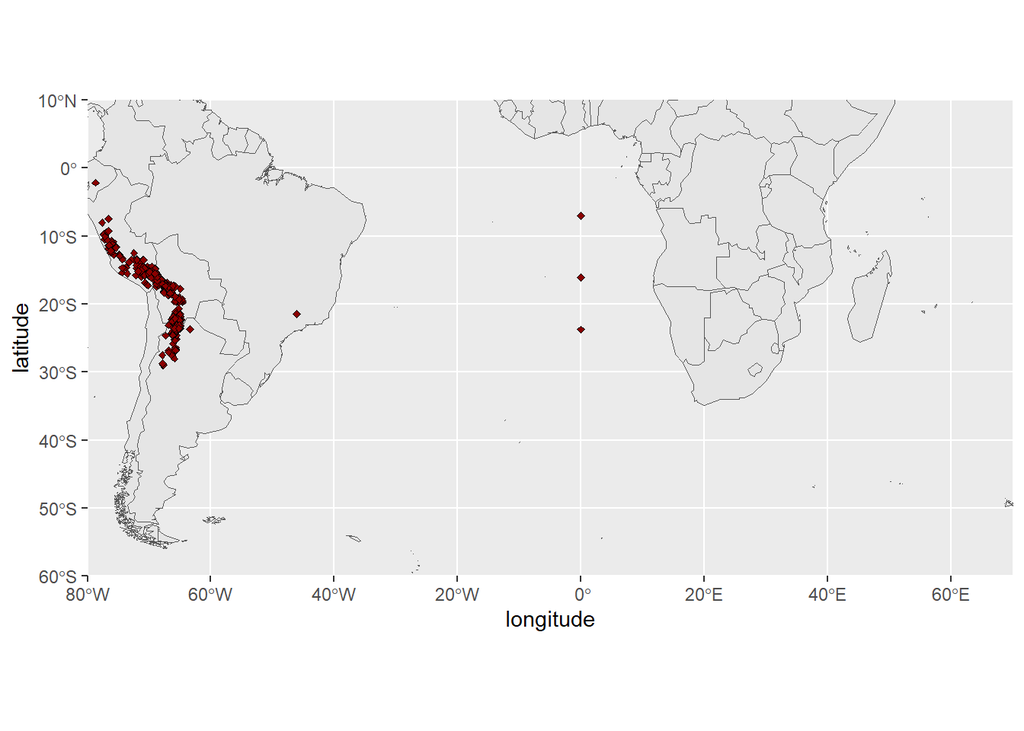

```r
library(ggplot2)
wrld_simpl_1 = st_read("wrld_simpl.shp")
Puntos1 = data.frame(acgeo$lon, acgeo$lat)
names(Puntos1) = c("longitude","latitude")
ggplot(data = wrld_simpl_1) +
    geom_sf() +
    geom_point(data = Puntos1, aes(x = longitude, y = latitude), size = 1,
        shape = 23, fill = "darkred")+
    coord_sf(xlim = c(-80, 70), ylim = c(-60, 10), expand = FALSE)
```

The wrld_simpl_1 dataset contains rough country outlines. You can use other datasets of polygons as well. For example, you can download higher resolution data country and sub national administrative boundaries data.

**Data cleaning.**

Data cleaning is particularly important for data sourced from species distribution data warehouses such as GBIF. Such efforts do not specifically gather data for the purpose of species distribution modeling, so you need to understand the data and clean them appropriately, for your application. Here we provide an example. Solanum acaule is a species that occurs in the higher parts of the Andes mountains of southern Peru, Bolivia and northern Argentina. Do you see any errors on the map?

There are a few records that map in the ocean just south of Pakistan. Any idea why that may have happened? It is a common mistake, missing minus signs. The coordinates are around (65.4, 23.4) but they should in Northern Argentina, around (-65.4, -23.4) (you can use the “click” function to query the coordintates on the map). There are two records (rows 303 and 885) that map to the same spot in Antarctica (-76.3, -76.3). The locality description says that is should be in Huarochiri, near Lima, Peru. So the longitude is probably correct, and erroneously copied to the latitude. Interestingly the record occurs twice. The orignal source is the International Potato Center, and a copy is provided by “SINGER” that aling the way appears to have “corrected” the country to Antarctica:

```r
acaule[c(303,885),1:10]
```

```
##                          species continent    country adm1 adm2
## 303        solanum acaule acaule      <NA> Antarctica <NA> <NA>
## 885 solanum acaule acaule BITTER      <NA>       Peru <NA> <NA>
##                         locality   lat   lon coordUncertaintyM  alt
## 303                         <NA> -76.3 -76.3              <NA>  NaN
## 885 Lima P. Huarochiri Pacomanta -76.3 -76.3              <NA> 3800
```

The point in Brazil (record acaule[98,]) should be in soutern Bolivia, so this is probably due to a typo in the longitude. Likewise, there are also three records that have plausible latitudes, but longitudes that are clearly wrong, as they are in the Atlantic Ocean, south of West Africa. It looks like they have a longitude that is zero. In many data-bases you will find values that are ‘zero’ where ‘no data’ was intended. The gbif function (when using the default arguments) sets coordinates that are (0, 0) to NA, but not if one of the coordinates is zero. Let’s see if we find them by searching for records with longitudes of zero.

Let’s have a look at these records:

```r
lonzero = subset(acgeo, lon==0)
# To show records
lonzero[, 1:13]
```

```
##                                  species continent   country adm1 adm2
## 1159 Solanum acaule Bitter subsp. acaule      <NA> Argentina <NA> <NA>
## 1160 Solanum acaule Bitter subsp. acaule      <NA>   Bolivia <NA> <NA>
## 1161 Solanum acaule Bitter subsp. acaule      <NA>      Peru <NA> <NA>
## 1162 Solanum acaule Bitter subsp. acaule      <NA>      Peru <NA> <NA>
## 1163 Solanum acaule Bitter subsp. acaule      <NA> Argentina <NA> <NA>
## 1164 Solanum acaule Bitter subsp. acaule      <NA>   Bolivia <NA> <NA>
##                                              locality        lat lon
## 1159 between Quelbrada del Chorro and Laguna Colorada -23.716667   0
## 1160                                            Llave -16.083334   0
## 1161                    km 205 between Puno and Cuzco  -6.983333   0
## 1162                    km 205 between Puno and Cuzco  -6.983333   0
## 1163 between Quelbrada del Chorro and Laguna Colorada -23.716667   0
## 1164                                            Llave -16.083334   0
##      coordUncertaintyM  alt institution collection catalogNumber
## 1159              <NA> 3400         IPK         GB     WKS 30027
## 1160              <NA> 3900         IPK         GB     WKS 30050
## 1161              <NA> 4250         IPK  WKS 30048        304709
## 1162              <NA> 4250         IPK         GB     WKS 30048
## 1163              <NA> 3400         IPK  WKS 30027        304688
## 1164              <NA> 3900         IPK  WKS 30050        304711
```

The records are from Bolivia, Peru and Argentina, confirming that coordinates are in error. Alternatively, it could have been that the coordinates were correct, perhaps referring to a location in the Atlantic Ocean where a fish was caught rather than a place where S. acaule was collected). Records with the wrong species name can be among the hardest to correct (e.g., distinguishing between brown bears and sasquatch, Lozier et al., 2009). The one record in Ecuador is like that, there is some debate whether that is actually a specimen of S. albicans or an anomalous hexaploid variety of S. acaule.

**Duplicate records.**

Interestingly, another data quality issue is revealed above: each record in ‘lonzero’ occurs twice. This could happen because plant samples are often split and send to multiple herbariums. But in this case it seems that the IPK (The Leibniz Institute of Plant Genetics and Crop Plant Research) provided these data twice to the GBIF database (perhaps from seperate databases at IPK?). The function ‘duplicated’ can sometimes be used to remove duplicates.

```r
dups = duplicated(lonzero[, 1:10])
# remove duplicates
lonzero  =  lonzero[dups, ]
lonzero[,1:13]
```

```
##                                  species continent   country adm1 adm2
## 1162 Solanum acaule Bitter subsp. acaule      <NA>      Peru <NA> <NA>
## 1163 Solanum acaule Bitter subsp. acaule      <NA> Argentina <NA> <NA>
## 1164 Solanum acaule Bitter subsp. acaule      <NA>   Bolivia <NA> <NA>
##                                              locality        lat lon
## 1162                    km 205 between Puno and Cuzco  -6.983333   0
## 1163 between Quelbrada del Chorro and Laguna Colorada -23.716667   0
## 1164                                            Llave -16.083334   0
##      coordUncertaintyM  alt institution collection catalogNumber
## 1162              <NA> 4250         IPK         GB     WKS 30048
## 1163              <NA> 3400         IPK  WKS 30027        304688
## 1164              <NA> 3900         IPK  WKS 30050        304711
```

Another approach might be to detect duplicates for the same species and some coordinates in the data, even if the records were from collections by different people or in different years (in our case, using species is redundant as we have data for only one species).

```r
# differentiating by (sub) species
# dups2 <- duplicated(acgeo[, c('species', 'lon', 'lat')])
# ignoring (sub) species and other naming variation
dups2 <- duplicated(acgeo[, c('lon', 'lat')])
# number of duplicates
sum(dups2)
```

```
## [1] 483
```

```r
## [1] 483
# keep the records that are _not_ duplicated
acg <- acgeo[!dups2, ]
```

Let’s repatriate the records near Pakistan to Argentina, and remove the records in Brazil, Antarctica, and with longitude=0

```r
i <- acg$lon > 0 & acg$lat > 0
acg$lon[i] <- -1 * acg$lon[i]
acg$lat[i] <- -1 * acg$lat[i]
acg <- acg[acg$lon < -50 & acg$lat > -50, ]
str(acg)
```

```
## 'data.frame':    594 obs. of  25 variables:
##  $ species              : chr  "Solanum acaule Bitter" "Solanum acaule Bitter" "Solanum acaule f. acaule" "Solanum acaule f. acaule" ...
##  $ continent            : chr  "South America" "South America" NA NA ...
##  $ country              : chr  "Argentina" "Peru" "Argentina" "Bolivia" ...
##  $ adm1                 : chr  "Jujuy" "Cusco" NA NA ...
##  $ adm2                 : chr  "Santa Catalina" "Canchis" NA NA ...
##  $ locality             : chr  "Santa Catalina: camino de salida del pueblo" "Dist. Sicuani, Santa Barbara, Mumurani." "Province: Salta, Department: Santa Victoria, East side of Abra de Lizoite." "Department: Oruro, Province: Poopo, farm (Finke St. Helena), 5km from Plazna to Lago Poopo." ...
##  $ lat                  : num  -21.9 -13.5 -22.3 -18.6 -18.8 ...
##  $ lon                  : num  -66.1 -71 -65.1 -67 -65.9 ...
##  $ coordUncertaintyM    : chr  NA NA NA NA ...
##  $ alt                  : num  NaN 4500 3800 3700 4080 3780 4300 3250 4000 2950 ...
##  $ institution          : chr  "NY" "NY" "NLD037" "NLD037" ...
##  $ collection           : chr  "Herbarium" "Herbarium" "CGN-PGR" "CGN-PGR" ...
##  $ catalogNumber        : chr  "00745416" "00962455" "CGN17852" "CGN20620" ...
##  $ basisOfRecord        : chr  "specimen" "specimen" "unknown" "unknown" ...
##  $ collector            : chr  "G. C. Giberti" "A. Tupayachi H." NA NA ...
##  $ earliestDateCollected: chr  "1979-01-29" "2005-03-17" NA NA ...
##  $ latestDateCollected  : chr  "1979-01-29" "2005-03-17" NA NA ...
##  $ gbifNotes            : chr  "Data from GBIF data index - original values." "Data from GBIF data index - original values." "Data from GBIF data index - original values." "Data from GBIF data index - original values." ...
##  $ downloadDate         : Date, format: "2013-01-16" "2013-01-16" ...
##  $ maxElevationM        : chr  NA "4500" NA NA ...
##  $ minElevationM        : chr  NA "4500" "3800" "3700" ...
##  $ maxDepthM            : chr  NA NA NA NA ...
##  $ minDepthM            : chr  NA NA NA NA ...
##  $ ISO2                 : chr  "AR" "PE" "AR" "BO" ...
##  $ cloc                 : chr  "Santa Catalina: camino de salida del pueblo, Jujuy, Santa Catalina, Argentina, South America" "Dist. Sicuani, Santa Barbara, Mumurani., Cusco, Canchis, Peru, South America" "Province: Salta, Department: Santa Victoria, East side of Abra de Lizoite., Argentina" "Dep…
```

**Cross-checking.**

It is important to cross-check coordinates by visual and other means. One approach is to compare the country (and lower-level administrative subdivisions) of the site as specified by the records, with the country implied by the coordinates (Hijmans et al., 1999). In the example below we use the coordinates function from the sp package to create a SpatialPointsDataFrame, and then the over function, also from sp, to do a point-in-polygon query with the countries polygons. This process has not been updated to run using the sf package. We can also do a spatial query of the polygons using the function over().

```r
#acg_2 = st_as_sf(acg, coords = c("lon", "lat"),
    #crs = 4326, agr = "constant")

#ovr <- over(acg, wrld_simpl)

library(sp)
library(maptools)
data(wrld_simpl)
coordinates(acg) <- ~lon+lat
crs(acg) <- crs(wrld_simpl)
class(acg)
```

```
## [1] "SpatialPointsDataFrame"
## attr(,"package")
## [1] "sp"
```

```r
#
ovr = over(acg, wrld_simpl)
str(ovr)
```

```
## 'data.frame':    594 obs. of  11 variables:
##  $ FIPS     : Factor w/ 244 levels "","AC","AE","AF",..: 12 169 12 26 26 26 12 12 12 12 ...
##  $ ISO2     : Factor w/ 246 levels "AD","AE","AF",..: 11 173 11 30 30 30 11 11 11 11 ...
##  $ ISO3     : Factor w/ 246 levels "ABW","AFG","AGO",..: 10 175 10 32 32 32 10 10 10 10 ...
##  $ UN       : int  32 604 32 68 68 68 32 32 32 32 ...
##  $ NAME     : Factor w/ 246 levels "Aaland Islands",..: 11 172 11 27 27 27 11 11 11 11 ...
##  $ AREA     : int  273669 128000 273669 108438 108438 108438 273669 273669 273669 273669 ...
##  $ POP2005  : num  38747148 27274266 38747148 9182015 9182015 ...
##  $ REGION   : int  19 19 19 19 19 19 19 19 19 19 ...
##  $ SUBREGION: int  5 5 5 5 5 5 5 5 5 5 ...
##  $ LON      : num  -65.2 -75.6 -65.2 -64.7 -64.7 ...
##  $ LAT      : num  -35.38 -9.33 -35.38 -16.71 -16.71 ...
```

Object ovr has, for each point, the matching record from wrld_simpl. We need the variable ‘NAME’ in the data.frame of wrld_simpl.

```r
head(ovr)
```

```
##   FIPS ISO2 ISO3  UN      NAME   AREA  POP2005 REGION SUBREGION     LON     LAT
## 1   AR   AR  ARG  32 Argentina 273669 38747148     19         5 -65.167 -35.377
## 2   PE   PE  PER 604      Peru 128000 27274266     19         5 -75.552  -9.326
## 3   AR   AR  ARG  32 Argentina 273669 38747148     19         5 -65.167 -35.377
## 4   BL   BO  BOL  68   Bolivia 108438  9182015     19         5 -64.671 -16.715
## 5   BL   BO  BOL  68   Bolivia 108438  9182015     19         5 -64.671 -16.715
## 6   BL   BO  BOL  68   Bolivia 108438  9182015     19         5 -64.671 -16.715
```

```r
cntr = ovr$NAME
```

We should ask these two questions: (1) Which points (identified by their record numbers) do not match any country (that is, they are in an ocean)? (There are none (because we already removed the points that mapped in the ocean)). (2) Which points have coordinates that are in a different country than listed in the ‘country’ field of the gbif record.

```r
i = which(is.na(cntr))
i
```

```
## integer(0)
```

```r
## integer(0)
j = which(cntr != acg$country)
# for the mismatches, bind the country names of the polygons and points
cbind(cntr, acg$country)[j,]
```

```
##      cntr
## [1,] "27"  "Argentina"
## [2,] "172" "Bolivia"
## [3,] "172" "Bolivia"
## [4,] "172" "Bolivia"
```

In this case the mismatch is probably because wrld_simpl is not very precise as the records map to locations very close to the border between Bolivia and its neighbors.

```r
plot(acg)
```

[output not shown]

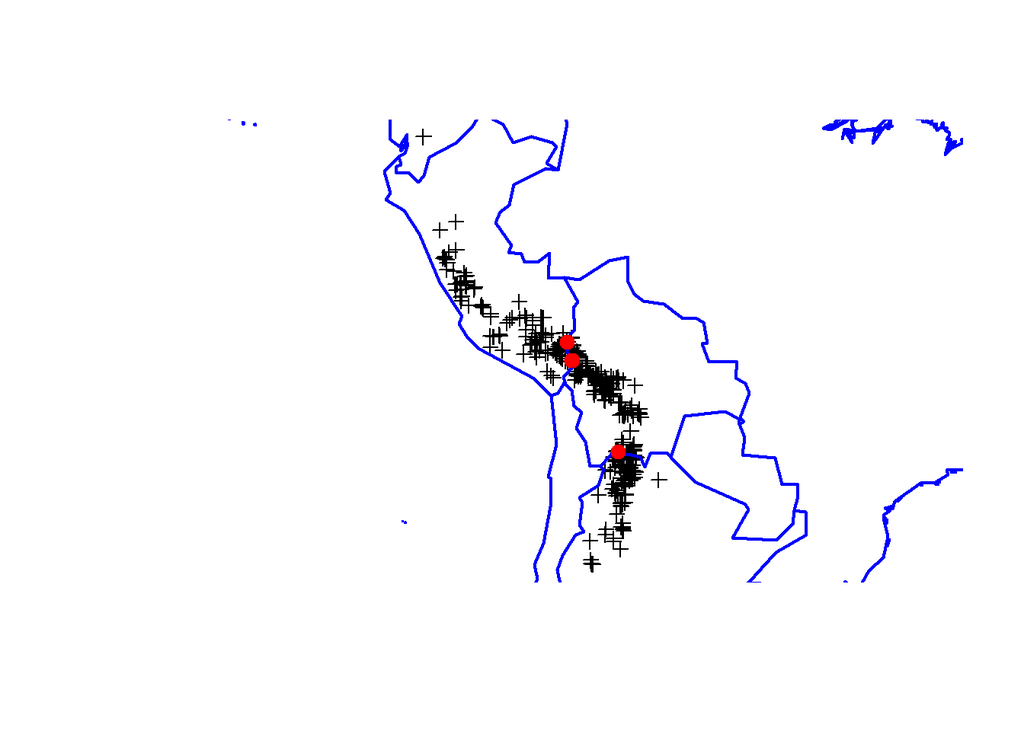

```r
plot(wrld_simpl, add=T, border='blue', lwd=2)
points(acg[j, ], col='red', pch=20, cex=2)
```

**Sampling bias.**

Sampling bias is frequently present in occurrence records (Hijmans et al., 2001). One can attempt to remove some of the bias by subsampling records, and this is illustrated below. However, subsampling reduces the number of records, and it cannot correct the data for areas that have not been sampled at all. It also suffers from the problem that locally dense records might in fact be a true reflection of the relative suitable of habitat. As in many steps in SDM, you need to understand something about your data and species to implement them well. See Phillips et al. (2009) for an approach with MaxEnt to deal with bias in occurrence records for a group of species.

```r
# create a RasterLayer with the extent of acgeo
r = raster(acg)
# set the resolution of the cells to (for example) 1 degree
res(r) = 1
# expand (extend) the extent of the RasterLayer a little (one degree)
r = extend(r, extent(r)+1)
# sample:
acsel = gridSample(acg, r, n=1)#SUPER IMPORTANT
dim(acg)
```

```
## [1] 594  23
```

```r
dim(acsel)
```

```
## [1] 64  2
```

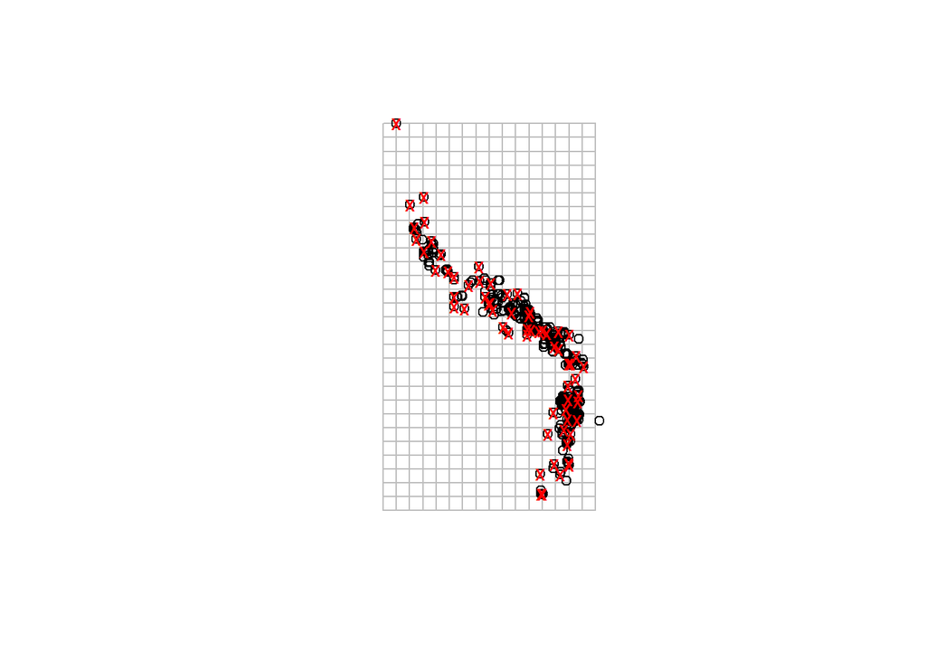

```r
# to illustrate the method and show the result
p = rasterToPolygons(r)
plot(p, border='gray')
points(acg)
# selected points in red
points(acsel, cex=1, col='red', pch='x')
```

At this point, it could be useful to save the cleaned data set. For example with the function write.table or write.csv so that we can use them later.

```r
#write.csv(acsel, file = "acsel.csv", row.names = F)
```

**Absence and background points.**

Some of the early species distribution model algorithms, such as Bioclim and Domain only use ‘presence’ data in the modeling process. Other methods also use ‘absence’ data or ‘background’ data. If you have a large dataset with presence/absence from a well designed survey, you should use a method that can use these data (i.e. do not use a modeling method that only considers presence data). If you only have presence data, you can still use a method that needs absence data, by substituting absence data with background data.

Background data (e.g. Phillips et al. 2009) are not attempting to guess at absence locations, but rather to characterize environments in the study region. In this sense, background is the same, irrespective of where the species has been found. Background data establishes the environmental domain of the study, whilst presence data should establish under which conditions a species is more likely to be present than on average. A closely related but different concept, that of “pseudo-absences”, is also used for generating the non-presence class for logistic models. In this case, researchers sometimes try to guess where absences might occur - they may sample the whole region except at presence locations, or they might sample at places unlikely to be suitable for the species. We prefer the background concept because it requires fewer assumptions and has some coherent statistical methods for dealing with the “overlap” between presence and background points (e.g. Ward et al. 2009; Phillips and Elith, 2011).

Survey-absence data has value. In conjunction with presence records, it establishes where surveys have been done, and the prevalence of the species given the survey effort. That information is lacking for presence-only data, a fact that can cause substantial difficulties for modeling presence-only data well. However, absence data can also be biased and incomplete, as discussed in the literature on detectability.

The dismo package has a function to sample random points (background data) from a study area. You can use a ‘mask’ to exclude area with no data NA, e.g. areas not on land. You can use an ‘extent’ to further restrict the area from which random locations are drawn.

In the example below, we first get the list of filenames with the predictor raster data (discussed in detail in the next chapter). We use a raster as a ‘mask’ in the randomPoints function such that the background points are from the same geographic area, and only for places where there are values (land, in our case).

Note that if the mask has the longitude/latitute coordinate reference system, function randomPoints selects cells according to cell area, which varies by latitude (as in Elith et al., 2011)

```r
# get the file names
files = list.files(path=paste(system.file(package="dismo"), '/ex',
                       sep=''),  pattern='grd',  full.names=TRUE )
# we use the first file to create a RasterLayer
mask = raster(files[1])
# select 500 random points
# set seed to assure that the examples will always
# have the same random sample.
set.seed(1963)
bg = randomPoints(mask, 500 )
```

To inspect the results by plotting

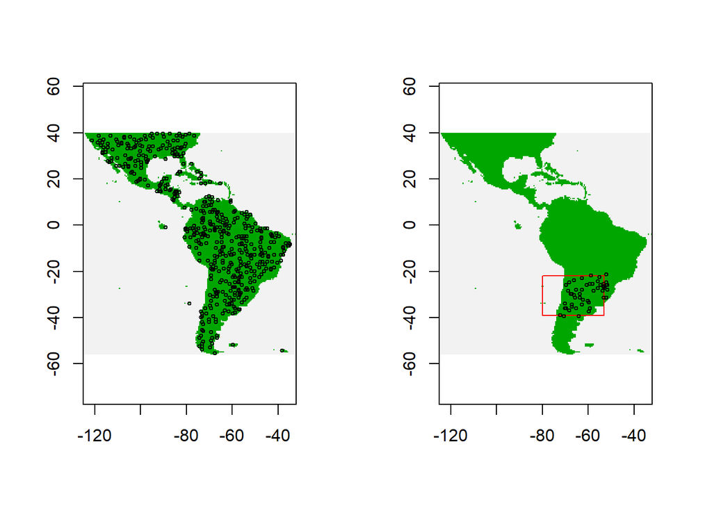

```r
# set up the plotting area for two maps
par(mfrow=c(1,2))
plot(!is.na(mask), legend=FALSE)
points(bg, cex=0.5)
# now we repeat the sampling, but limit
# the area of sampling using a spatial extent
e <- extent(-80, -53, -39, -22)
bg2 <- randomPoints(mask, 50, ext=e)
plot(!is.na(mask), legend=FALSE)
plot(e, add=TRUE, col='red')
points(bg2, cex=0.5)
```

**Environmental data.**

**Raster data** In SDM, predictor variables are typically organized as raster (grid) type files. Each predictor should be a ‘raster’ representing a variable of interest. Variables can include climatic, soil, terrain, vegetation, land use, and other variables. These data are typically stored in files in some kind of GIS format. Almost all relevant formats can be used (including ESRI grid, geoTiff, netCDF, IDRISI). For any particular study the layers should all have the same spatial extent, resolution, origin, and projection.

Here we make a list of files that are installed with the dismo package and then create a rasterStack from these, show the names of each layer, and finally plot them all. First get the folder with our files. In this example it is the (“ex”) directory of the dismo package. You do not need such a complex statement to get your own files (you just type the string).

```r
path <- file.path(system.file(package="dismo"), 'ex')
```

Now get the names of all the files with extension “.grd” in this folder. The $ sign indicates that the files must end with the characters ‘grd’. By using full.names=TRUE, the full path names are retunred.

```r
files <- list.files(path, pattern='grd$', full.names=TRUE )
files
```

```
## [1] "C:/Users/camil/AppData/Local/R/win-library/4.3/dismo/ex/bio1.grd"
## [2] "C:/Users/camil/AppData/Local/R/win-library/4.3/dismo/ex/bio12.grd"
## [3] "C:/Users/camil/AppData/Local/R/win-library/4.3/dismo/ex/bio16.grd"
## [4] "C:/Users/camil/AppData/Local/R/win-library/4.3/dismo/ex/bio17.grd"
## [5] "C:/Users/camil/AppData/Local/R/win-library/4.3/dismo/ex/bio5.grd"
## [6] "C:/Users/camil/AppData/Local/R/win-library/4.3/dismo/ex/bio6.grd"
## [7] "C:/Users/camil/AppData/Local/R/win-library/4.3/dismo/ex/bio7.grd"
## [8] "C:/Users/camil/AppData/Local/R/win-library/4.3/dismo/ex/bio8.grd"
## [9] "C:/Users/camil/AppData/Local/R/win-library/4.3/dismo/ex/biome.grd"
```

Now create a RasterStack of predictor variables.

```r
predictors <- stack(files)
predictors
```

```
## class      : RasterStack
## dimensions : 192, 186, 35712, 9  (nrow, ncol, ncell, nlayers)
## resolution : 0.5, 0.5  (x, y)
## extent     : -125, -32, -56, 40  (xmin, xmax, ymin, ymax)
## crs        : +proj=longlat +datum=WGS84 +no_defs
## names      : bio1, bio12, bio16, bio17, bio5, bio6, bio7, bio8, biome
## min values :  -23,     0,     0,     0,   61, -212,   60,  -66,     1
## max values :  289,  7682,  2458,  1496,  422,  242,  461,  323,    14
```

```r
names(predictors)
```

```
## [1] "bio1"  "bio12" "bio16" "bio17" "bio5"  "bio6"  "bio7"  "bio8"  "biome"
```

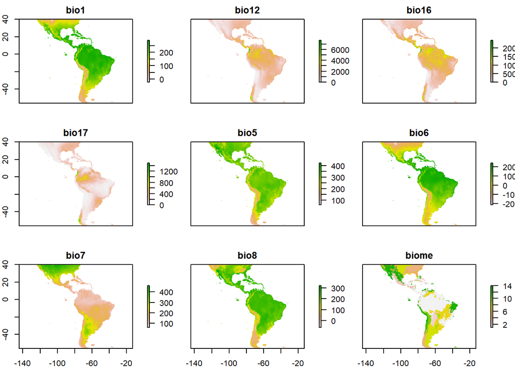

```r
plot(predictors)
```

We can also make a plot of a single layer in a RasterStack, and plot some additional data on top of it. First get the world boundaries and the bradypus data:

```r
library(maptools)
data(wrld_simpl)
file <- paste(system.file(package="dismo"), "/ex/bradypus.csv", sep="")
bradypus <- read.table(file,  header=TRUE,  sep=',')
# we do not need the first column
bradypus  <- bradypus[,-1]
```

And now plot:

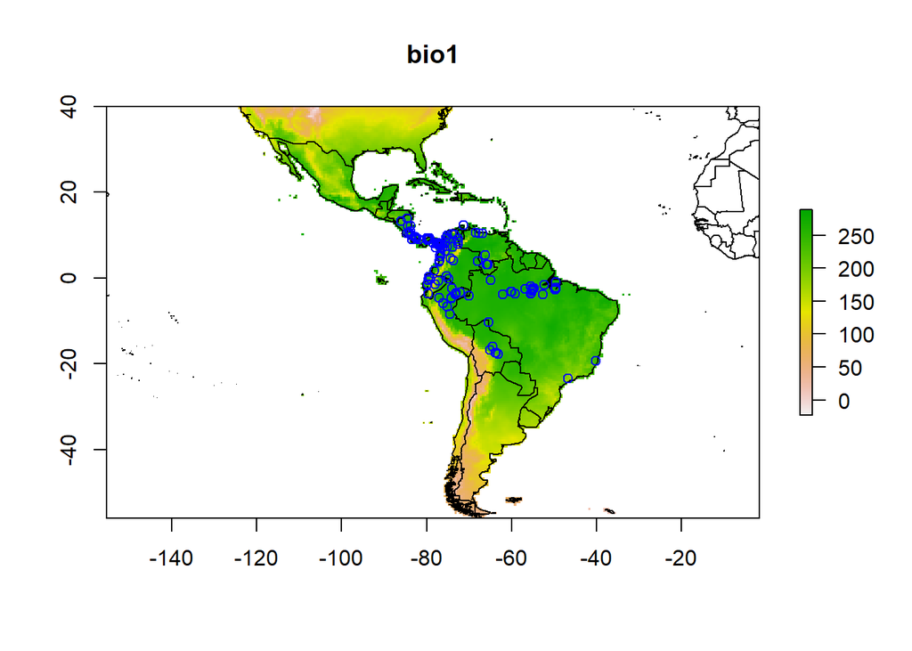

```r
# first layer of the RasterStack
plot(predictors, 1)
# note the "add=TRUE" argument with plot
plot(wrld_simpl, add=TRUE)
# with the points function, "add" is implicit
points(bradypus, col='blue')
```

he example above uses data representing ‘bioclimatic variables’ from the [WorldClim](https://www.worldclim.org/) database (Hijmans et al., 2004) and [terrestrial biome](https://www.worldwildlife.org/publications/terrestrial-ecoregions-of-the-world) data from the WWF (Olsen et al., 2001). For species variable selection is critically important, for that reason, it is important to use variables that are relevant to the ecology of the species.

**Extracting values from rasters** We now have a set of predictor variables (rasters) and occurrence points. The next step is to extract the values of the predictors at the locations of the points. (This step can be skipped for the modeling methods that are implemented in the dismo package). This is a very straightforward thing to do using the ‘extract’ function from the raster package. In the example below we use that function first for the Bradypus occurrence points, then for 500 random background points. We combine these into a single data.frame in which the first column (variable ‘pb’) indicates whether this is a presence or a background point. ‘biome’ is categorical variable (called a ‘factor’ in R) and it is important to explicitly define it that way, so that it won’t be treated like any other numerical variable.

```r
presvals = extract(predictors, bradypus)
# setting random seed to always create the same
# random set of points for this example
set.seed(0)
backgr = randomPoints(predictors, 500)
absvals = extract(predictors, backgr)
pb = c(rep(1, nrow(presvals)), rep(0, nrow(absvals)))
pb
```

```
##   [1] 1 1 1 1 1 1 1 1 1 1 1 1 1 1 1 1 1 1 1 1 1 1 1 1 1 1 1 1 1 1 1 1 1 1 1 1 1
##  [38] 1 1 1 1 1 1 1 1 1 1 1 1 1 1 1 1 1 1 1 1 1 1 1 1 1 1 1 1 1 1 1 1 1 1 1 1 1
##  [75] 1 1 1 1 1 1 1 1 1 1 1 1 1 1 1 1 1 1 1 1 1 1 1 1 1 1 1 1 1 1 1 1 1 1 1 1 1
## [112] 1 1 1 1 1 0 0 0 0 0 0 0 0 0 0 0 0 0 0 0 0 0 0 0 0 0 0 0 0 0 0 0 0 0 0 0 0
## [149] 0 0 0 0 0 0 0 0 0 0 0 0 0 0 0 0 0 0 0 0 0 0 0 0 0 0 0 0 0 0 0 0 0 0 0 0 0
## [186] 0 0 0 0 0 0 0 0 0 0 0 0 0 0 0 0 0 0 0 0 0 0 0 0 0 0 0 0 0 0 0 0 0 0 0 0 0
## [223] 0 0 0 0 0 0 0 0 0 0 0 0 0 0 0 0 0 0 0 0 0 0 0 0 0 0 0 0 0 0 0 0 0 0 0 0 0
## [260] 0 0 0 0 0 0 0 0 0 0 0 0 0 0 0 0 0 0 0 0 0 0 0 0 0 0 0 0 0 0 0 0 0 0 0 0 0
## [297] 0 0 0 0 0 0 0 0 0 0 0 0 0 0 0 0 0 0 0 0 0 0 0 0 0 0 0 0 0 0 0 0 0 0 0 0 0
## [334] 0 0 0 0 0 0 0 0 0 0 0 0 0 0 0 0 0 0 0 0 0 0 0 0 0 0 0 0 0 0 0 0 0 0 0 0 0
## [371] 0 0 0 0 0 0 0 0 0 0 0 0 0 0 0 0 0 0 0 0 0 0 0 0 0 0 0 0 0 0 0 0 0 0 0 0 0
## [408] 0 0 0 0 0 0 0 0 0 0 0 0 0 0 0 0 0 0 0 0 0 0 0 0 0 0 0 0 0 0 0 0 0 0 0 0 0
## [445] 0 0 0 0 0 0 0 0 0 0 0 0 0 0 0 0 0 0 0 0 0 0 0 0 0 0 0 0 0 0 0 0 0 0 0 0 0
## [482] 0 0 0 0 0 0 0 0 0 0 0 0 0 0 0 0 0 0 0 0 0 0 0 0 0 0 0 0 0 0 0 0 0 0 0 0 0
## [519] 0 0 0 0 0 0 0 0 0 0 0 0 0 0 0 0 0 0 0 0 0 0 0 0 0 0 0 0 0 0 0 0 0 0 0 0 0
## [556] 0 0 0 0 0 0 0 0 0 0 0 0 0 0 0 0 0 0 0 0 0 0 0 0 0 0 0 0 0 0 0 0 0 0 0 0 0
## [593] 0 0 0 0 0 0 0 0 0 0 0 0 0 0 0 0 0 0 0 0 0 0 0 0
```

```r
sdmdata = data.frame(cbind(pb, rbind(presvals, absvals)))
sdmdata[,'biome'] = as.factor(sdmdata[,'biome'])
head(sdmdata)
```

```
##   pb bio1 bio12 bio16 bio17 bio5 bio6 bio7 bio8 biome
## 1  1  263  1639   724    62  338  191  147  261     1
## 2  1  263  1639   724    62  338  191  147  261     1
## 3  1  253  3624  1547   373  329  150  179  271     1
## 4  1  243  1693   775   186  318  150  168  264     1
## 5  1  243  1693   775   186  318  150  168  264     1
## 6  1  252  2501  1081   280  326  154  172  270     1
```

To visually investigate colinearity in the environmental data (at the presence and background points) you can use a pairs plot.

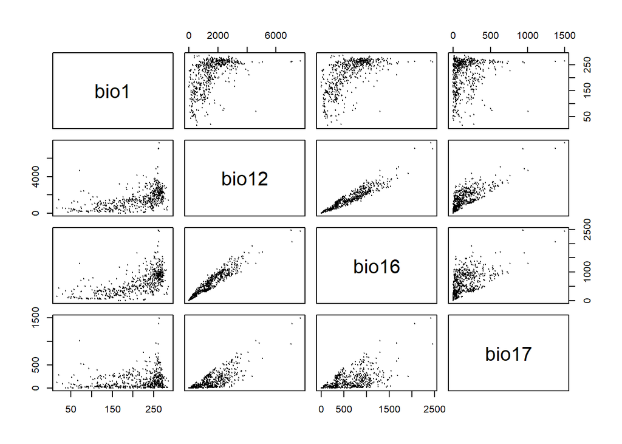

```r
pairs(sdmdata[,2:5], cex=0.1)
```

To use the sdmdata and presvals later, we save these to disk

```r
#saveRDS(sdmdata, "sdm.Rds")
#saveRDS(presvals, "pvals.Rds")
```

# **IV. Model fitting, prediction, and evaluation**

**Model fitting.**

Model fitting is technically quite similar across the modeling methods that exist in R. Most methods take a formula identifying the dependent and independent variables, accompanied with a data.frame that holds these variables. In the example below, the function glm is used to fit generalized linear models. glm returns a model object. We are using the data.frame ‘sdmdata’ again. First read sdmdata from disk (we saved it at the end of the previous chapter).

```r
sdmdata = readRDS("sdm.Rds")
presvals = readRDS("pvals.Rds")
class(sdmdata)
```

```
## [1] "data.frame"
```

```r
class(presvals)
```

```
## [1] "matrix" "array"
```

```r
str(sdmdata)
```

```
## 'data.frame':    616 obs. of  10 variables:
##  $ pb   : num  1 1 1 1 1 1 1 1 1 1 ...
##  $ bio1 : num  263 263 253 243 243 252 240 275 271 274 ...
##  $ bio12: num  1639 1639 3624 1693 1693 ...
##  $ bio16: num  724 724 1547 775 775 ...
##  $ bio17: num  62 62 373 186 186 280 146 208 281 230 ...
##  $ bio5 : num  338 338 329 318 318 326 317 335 327 329 ...
##  $ bio6 : num  191 191 150 150 150 154 150 231 220 227 ...
##  $ bio7 : num  147 147 179 168 168 172 168 104 107 102 ...
##  $ bio8 : num  261 261 271 264 264 270 261 270 266 269 ...
##  $ biome: Factor w/ 13 levels "1","2","3","4",..: 1 1 1 1 1 1 2 1 1 1 ...
```

```r
str(presvals)
```

```
##  num [1:116, 1:9] 263 263 253 243 243 252 240 275 271 274 ...
##  - attr(*, "dimnames")=List of 2
##   ..$ : NULL
##   ..$ : chr [1:9] "bio1" "bio12" "bio16" "bio17" ...
```

```r
m1 = glm(pb ~ bio1 + bio5 + bio12, data=sdmdata)
class(m1)
```

```
## [1] "glm" "lm"
```

```r
summary(m1)
```

```
##
## Call:
## glm(formula = pb ~ bio1 + bio5 + bio12, data = sdmdata)
##
## Coefficients:
##               Estimate Std. Error t value Pr(>|t|)
## (Intercept)  1.550e-01  1.093e-01   1.418 0.156593
## bio1         1.621e-03  3.960e-04   4.093 4.84e-05 ***
## bio5        -1.614e-03  4.725e-04  -3.417 0.000676 ***
## bio12        1.140e-04  1.676e-05   6.806 2.39e-11 ***
## ---
## Signif. codes:  0 '***' 0.001 '**' 0.01 '*' 0.05 '.' 0.1 ' ' 1
##
## (Dispersion parameter for gaussian family taken to be 0.1220413)
##
##     Null deviance: 94.156  on 615  degrees of freedom
## Residual deviance: 74.689  on 612  degrees of freedom
## AIC: 458.43
##
## Number of Fisher Scoring iterations: 2
```

```r
m2 = glm(pb ~ ., data=sdmdata)
summary(m1)
```

```
##
## Call:
## glm(formula = pb ~ bio1 + bio5 + bio12, data = sdmdata)
##
## Coefficients:
##               Estimate Std. Error t value Pr(>|t|)
## (Intercept)  1.550e-01  1.093e-01   1.418 0.156593
## bio1         1.621e-03  3.960e-04   4.093 4.84e-05 ***
## bio5        -1.614e-03  4.725e-04  -3.417 0.000676 ***
## bio12        1.140e-04  1.676e-05   6.806 2.39e-11 ***
## ---
## Signif. codes:  0 '***' 0.001 '**' 0.01 '*' 0.05 '.' 0.1 ' ' 1
##
## (Dispersion parameter for gaussian family taken to be 0.1220413)
##
##     Null deviance: 94.156  on 615  degrees of freedom
## Residual deviance: 74.689  on 612  degrees of freedom
## AIC: 458.43
##
## Number of Fisher Scoring iterations: 2
```

**NOTE ABOUT AIC:** The Akaike information criterion (AIC) is a mathematical method for evaluating how well a model fits the data it was generated from. In statistics, AIC is used to compare different possible models and determine which one is the best fit for the data. AIC is calculated from: 1) The number of independent variables used to build the model and 2) the maximum likelihood estimates of the model (how well the model reproduces the data). To apply AIC, we start with a set of candidate models, and then find the models’ corresponding AIC values. There will almost always be information lost due to using a candidate model to represent the “true model”. We wish to select the model that minimizes the information loss. We cannot choose with certainty, but we can minimize the estimated information loss, that is, the lowest AIC.

Models that are implemented in dismo do not use a formula (and most models only take presence points). Bioclim is an example. It only uses presence data, so we use ‘presvals’ instead of ‘sdmdata’.

```r
bc <- bioclim(presvals[,c('bio1', 'bio5', 'bio12')])
class(bc)
```

```
## [1] "Bioclim"
## attr(,"package")
## [1] "dismo"
```

```r
bc
```

```
## class    : Bioclim
##
## variables: bio1 bio5 bio12
##
##
## presence points: 116
##    bio1 bio5 bio12
## 1   263  338  1639
## 2   263  338  1639
## 3   253  329  3624
## 4   243  318  1693
## 5   243  318  1693
## 6   252  326  2501
## 7   240  317  1214
## 8   275  335  2259
## 9   271  327  2212
## 10  274  329  2233
##   (... ...  ...)
```

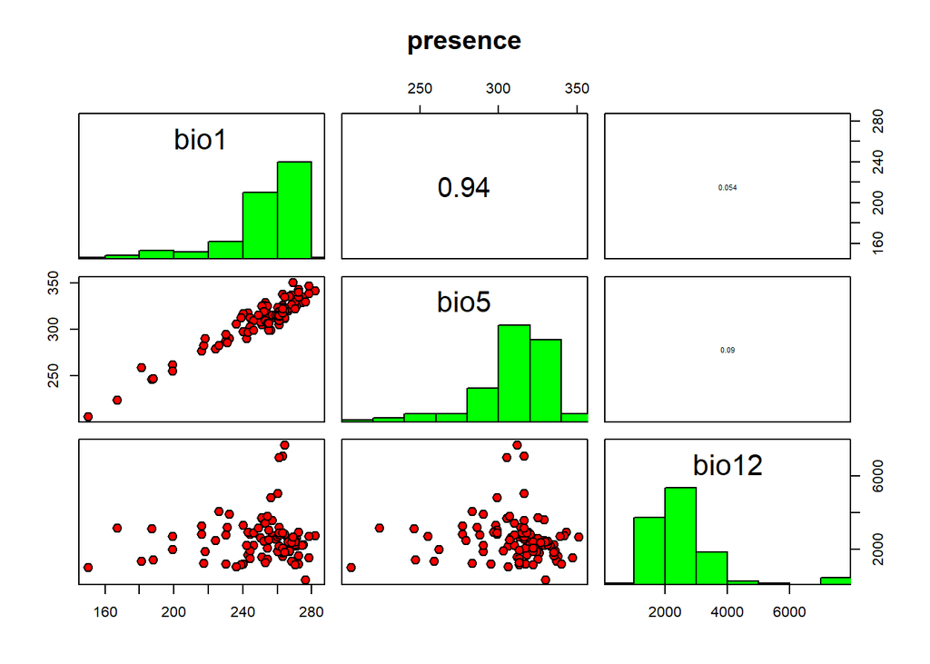

```r
pairs(bc)
```

**Model prediction.**

```r
bio1 = c(40, 150, 200)
bio5 = c(60, 115, 290)
bio12 = c(600, 1600, 1700)
pd = data.frame(cbind(bio1, bio5, bio12))
pd
```

```
##   bio1 bio5 bio12
## 1   40   60   600
## 2  150  115  1600
## 3  200  290  1700
```

```r
#
predict(m1, pd)
```

```
##         1         2         3
## 0.1914136 0.3949569 0.2048905
```

```r
#
```

Making such predictions for a few environments can be very useful to explore and understand model predictions. For example it used in the response function that creates response plots for each variable, with the other variables at their median value.

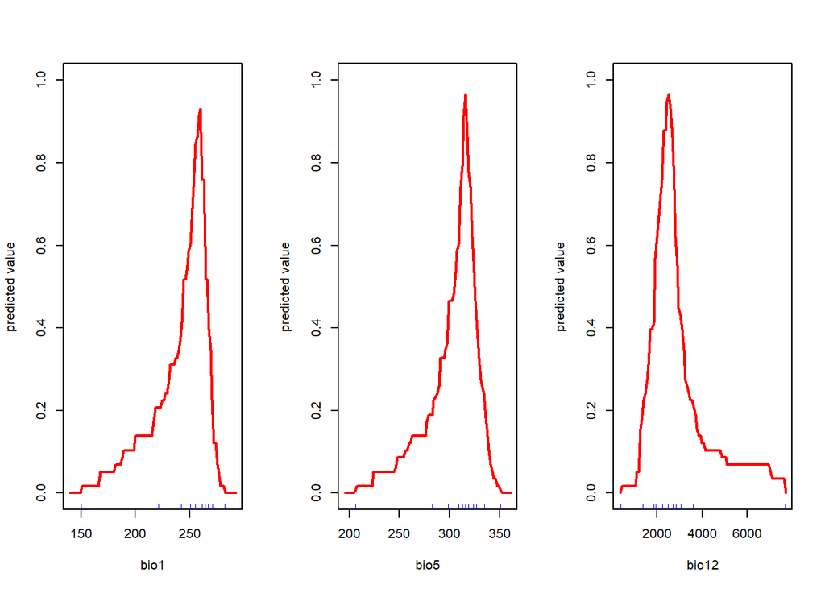

```r
response(bc)
```

In most cases, however, the purpose of SDM is to create a map of suitability scores. We can do that by providing the predict function with a Raster object and a model object. As long as the variable names in the model object are available as layers (layerNames) in the Raster* object.

```r
predictors <- stack(list.files(file.path(system.file(package="dismo"), 'ex'), pattern='grd$', full.names=TRUE ))

names(predictors)
```

```
## [1] "bio1"  "bio12" "bio16" "bio17" "bio5"  "bio6"  "bio7"  "bio8"  "biome"
```

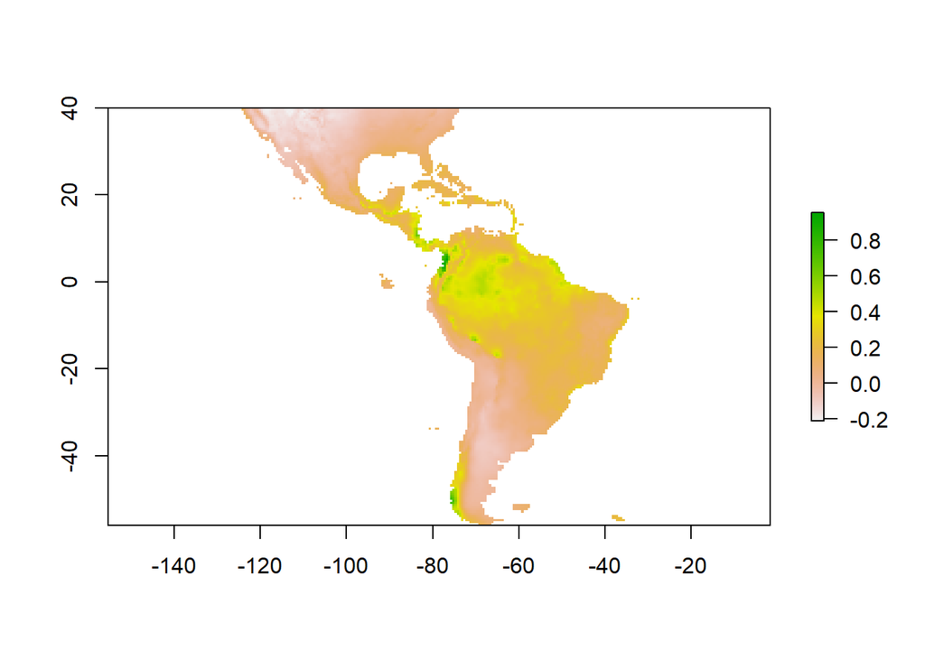

```r
p <- predict(predictors, m1)
plot(p)
```

**Model evaluation.**

Most modelers rely on cross-validation. This consists of creating a model with one ‘training’ data set, and testing it with another data set of known occurrences. Typically, training and testing data are created through random sampling (without replacement) from a single data set. Only in a few cases, e.g. Elith et al., 2006, training and test data are from different sources and pre-defined.

Different measures can be used to evaluate the quality of a prediction (Fielding and Bell, 1997, Liu et al., 2011; and Potts and Elith (2006) for abundance data), perhaps depending on the goal of the study. Many measures for evaluating models based on presence-absence or presence-only data are ‘threshold dependent’. That means that a threshold must be set first (e.g., 0.5, though 0.5 is rarely a sensible choice - e.g. see Lui et al. 2005). Predicted values above that threshold indicate a prediction of ‘presence’, and values below the threshold indicate ‘absence’. Some measures emphasize the weight of false absences; others give more weight to false presences.

Much used statistics that are threshold independent are the correlation coefficient and the Area Under the Receiver Operator Curve (AUROC, generally further abbreviated to AUC). AUC is a measure of rank-correlation. In unbiased data, a high AUC indicates that sites with high predicted suitability values tend to be areas of known presence and locations with lower model prediction values tend to be areas where the species is not known to be present (absent or a random point). An AUC score of 0.5 means that the model is as good as a random guess. See Phillips et al. (2006) for a discussion on the use of AUC in the context of presence-only rather than presence/absence data.